# Diamonds Exercise 3

Jonathan Morken

February 28, 2016

The following is my set of notes/results from performing the third Udacity Diamonds problem set.

### Section One - Create a histogram of diamond prices. Facet the histogram by diamond color and use cut to color the histogram bars. The plot should look something like this. http://i.imgur.com/b5xyrOu.jpg:

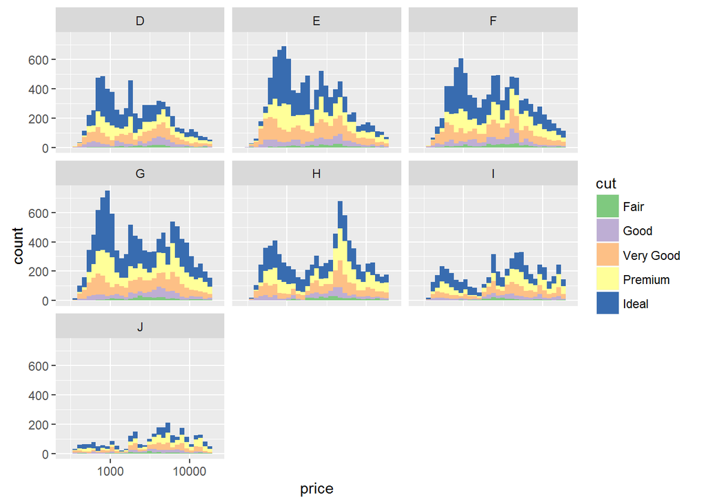

### Section Two - Create a scatterplot of diamond price vs. table and color the points by the cut of the diamond. The plot should look something like this. http://i.imgur.com/rQF9jQr.jpg

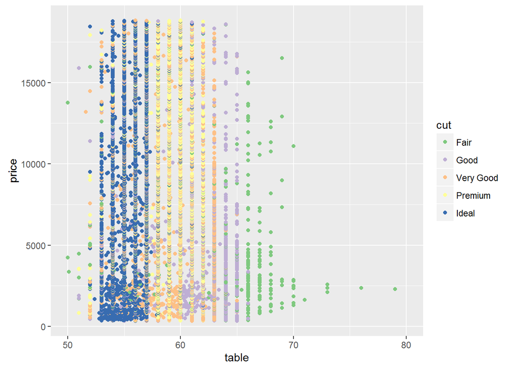

### Section Three - Create a scatterplot of diamond price vs. volume (x * y * z) and color the points by the clarity of diamonds.

Note: Use scale on the y-axis to take the log10 of price. You should also omit the top 1% of diamond volumes from the plot. The plot should look something like this. http://i.imgur.com/excUpea.jpg

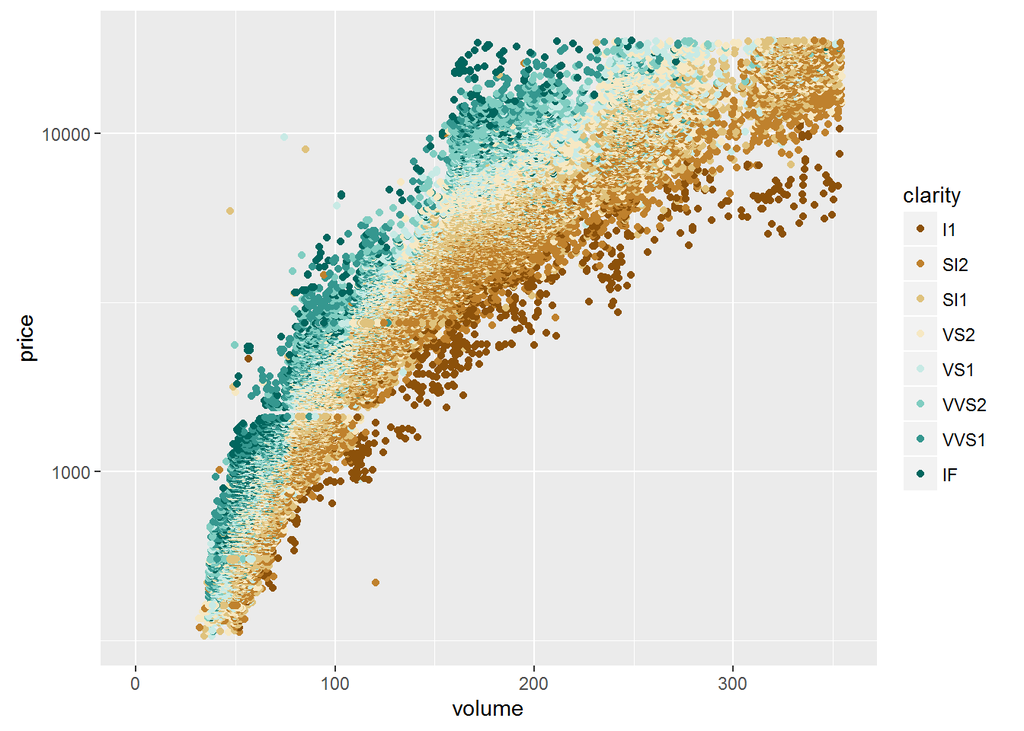

### Section Four - Switch to facebook data. Your task is to create a new variable called ‘prop_initiated’ in the Pseudo-Facebook data set.

The variable should contain the proportion of friendships that the user initiated.

```r
pf <- read.csv('pseudo_facebook.tsv',sep = '\t')
pf$prop_initiated <- pf$friendships_initiated/pf$friend_count
```

#### Part Two - Create a line graph of the median proportion of friendships initiated vs. tenure and color the line segment by year_joined.bucket as created in Lesson 5.

The plot should look something like this. http://i.imgur.com/vNjPtDh.jpg OR this http://i.imgur.com/IBN1ufQ.jpg

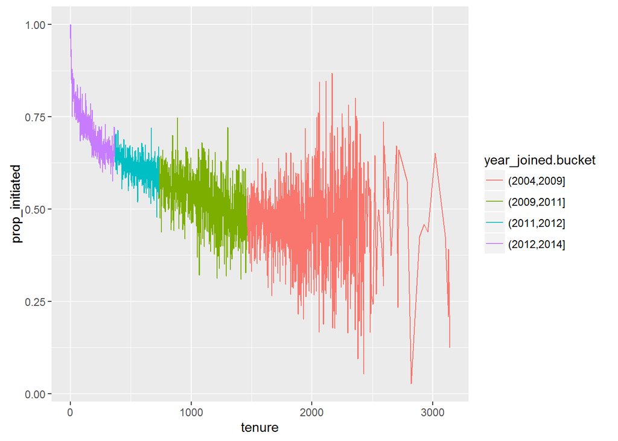

#### Part Three - Smooth the last plot you created of prop_initiated vs tenure colored by year_joined.bucket. You can bin together ranges of tenure or add a smoother to the plot.

I did both.

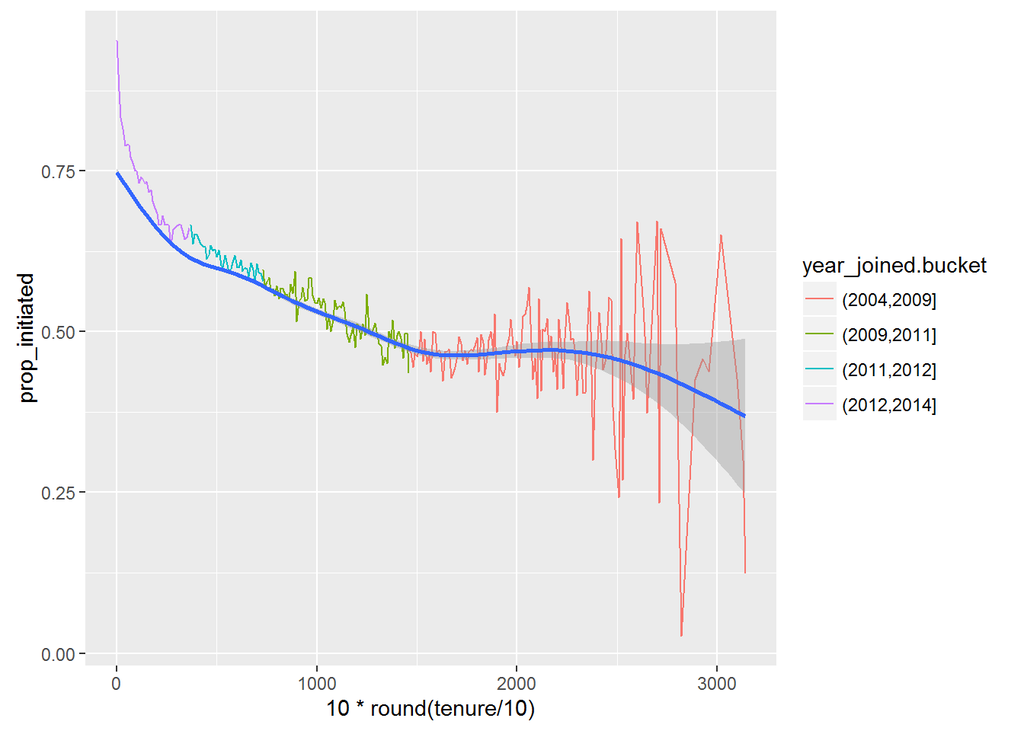

#### Part Four - Answers to questions

1. On average, people who joined between 2012 and 2014 have the highest proportion of friendships initiated.
2. What is that group of people’s mean proportion of friendships initiated?

```
## Source: local data frame [5 x 2]
##
##   year_joined.bucket mean_friendships_initiate
##               (fctr)                     (dbl)
## 1        (2004,2009]                 0.4668151
## 2        (2009,2011]                 0.5301298
## 3        (2011,2012]                 0.5984577
## 4        (2012,2014]                 0.6653892
## 5                 NA                 0.6168644
```

### Section Five - Going back to the Diamonds data set, create a scatter plot of the price/carat ratio of diamonds.

The variable x should be assigned to cut. The points should be colored by diamond color, and the plot should be faceted by clarity. The plot should look something like this. http://i.imgur.com/YzbWkHT.jpg.

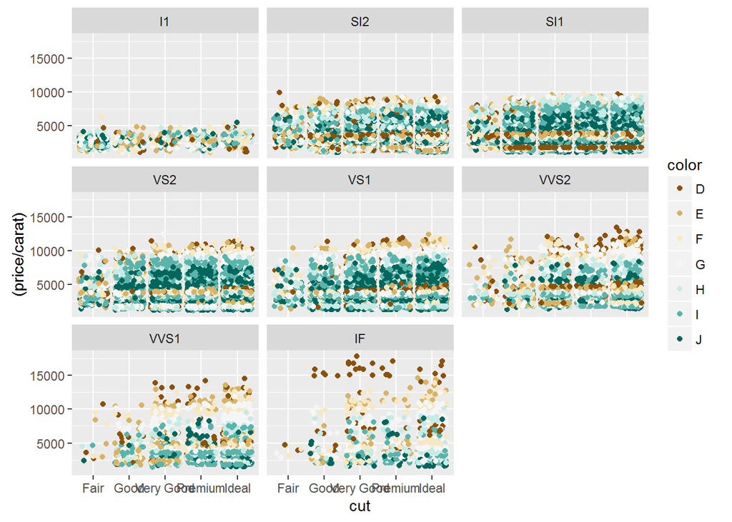